# 1. Domain Adaptation

```python
dann_classifier_model.summary()
```

```
Model: "dann_classifier_model"
```

```
┏━━━━━━━━━━━━━━━━━━━━━━━━━━━━━━━━━┳━━━━━━━━━━━━━━━━━━━━━━━━┳━━━━━━━━━━━━━━━┓
┃ Layer (type)                    ┃ Output Shape           ┃       Param # ┃
┡━━━━━━━━━━━━━━━━━━━━━━━━━━━━━━━━━╇━━━━━━━━━━━━━━━━━━━━━━━━╇━━━━━━━━━━━━━━━┩
│ dann_feature_extractor          │ (None, 128)            │       503,552 │
│ (Sequential)                    │                        │               │
├─────────────────────────────────┼────────────────────────┼───────────────┤
│ dann_label_classifier           │ (None, 10)             │         1,290 │
│ (Sequential)                    │                        │               │
└─────────────────────────────────┴────────────────────────┴───────────────┘
```

```
 Total params: 504,842 (1.93 MB)
```

```
 Trainable params: 504,842 (1.93 MB)
```

```
 Non-trainable params: 0 (0.00 B)
```

```python
dann_batch_size = 128

dann_source_dataset = tf.data.Dataset.from_tensor_slices((mnist_train_images, mnist_train_labels))
dann_source_dataset = dann_source_dataset.shuffle(len(mnist_train_images))
dann_source_dataset = dann_source_dataset.repeat()
dann_source_dataset = dann_source_dataset.batch(dann_batch_size)

dann_target_dataset = tf.data.Dataset.from_tensor_slices(usps_train_images)
dann_target_dataset = dann_target_dataset.shuffle(len(usps_train_images))
dann_target_dataset = dann_target_dataset.repeat()
dann_target_dataset = dann_target_dataset.batch(dann_batch_size)

dann_source_iter = iter(dann_source_dataset)
dann_target_iter = iter(dann_target_dataset)

dann_steps_per_epoch = len(usps_train_images) // dann_batch_size

print("DANN steps per epoch:", dann_steps_per_epoch)
```

```
DANN steps per epoch: 56
```

```python
dann_epochs = 50
dann_display_epoch_interval = 10

domain_weight = 0.1
target_entropy_weight = 0.1

dann_history = []

for epoch in range(1, dann_epochs + 1):
    total_loss_sum = 0.0
    class_loss_sum = 0.0
    domain_loss_sum = 0.0
    entropy_loss_sum = 0.0

    domain_correct = 0.0
    domain_count = 0.0

    for _ in range(dann_steps_per_epoch):
        source_x, source_y = next(dann_source_iter)
        target_x = next(dann_target_iter)

        domain_x = tf.concat([source_x, target_x], axis=0)
        domain_y = tf.concat([tf.zeros((dann_batch_size,), dtype=tf.int64), tf.ones((dann_batch_size,), dtype=tf.int64),], axis=0)

        with tf.GradientTape() as domain_tape:
            domain_feature = dann_feature_extractor(domain_x, training=True)
            domain_feature = tf.stop_gradient(domain_feature)

            domain_prob = dann_domain_classifier(domain_feature, training=True)
            domain_classifier_loss = domain_loss_fn(domain_y, domain_prob)

        dann_domain_optimizer.apply_gradients(
            zip(domain_tape.gradient(domain_classifier_loss,
                                     dann_domain_classifier.trainable_variables),
                dann_domain_classifier.trainable_variables))

        with tf.GradientTape(persistent=True) as feature_tape:
            source_feature = dann_feature_extractor(source_x, training=True)
            target_feature = dann_feature_extractor(target_x, training=True)

            source_class_prob = dann_label_classifier(source_feature, training=True)
            target_class_prob = dann_label_classifier(target_feature, training=True)

            source_domain_prob = dann_domain_classifier(source_feature, training=False)
            target_domain_prob = dann_domain_classifier(target_feature, training=False)

            domain_prob_for_feature = tf.concat([source_domain_prob, target_domain_prob], axis=0)

            class_loss = class_loss_fn(source_y, source_class_prob)

            domain_confusion_loss = domain_loss_fn(domain_y, domain_prob_for_feature)

            entropy_loss = -tf.reduce_mean(tf.reduce_sum(target_class_prob * tf.math.log(target_class_prob + 1e-8), axis=1))

            total_loss = (class_loss - domain_weight * domain_confusion_loss + target_entropy_weight * entropy_loss)

        dann_feature_optimizer.apply_gradients(
            zip(feature_tape.gradient(total_loss,
                                      dann_feature_extractor.trainable_variables),
                dann_feature_extractor.trainable_variables))

        dann_label_optimizer.apply_gradients(
            zip(feature_tape.gradient(total_loss,
                                      dann_label_classifier.trainable_variables),
                dann_label_classifier.trainable_variables))

        del feature_tape

        domain_pred = tf.argmax(domain_prob, axis=1, output_type=tf.int64)
        domain_correct += float(tf.reduce_sum(tf.cast(domain_pred == domain_y, tf.float32)))
        domain_count += float(tf.shape(domain_y)[0])

        total_loss_sum += float(total_loss)
        class_loss_sum += float(class_loss)
        domain_loss_sum += float(domain_classifier_loss)
        entropy_loss_sum += float(entropy_loss)

    total_loss_mean = total_loss_sum / dann_steps_per_epoch
    class_loss_mean = class_loss_sum / dann_steps_per_epoch
    domain_loss_mean = domain_loss_sum / dann_steps_per_epoch
    entropy_loss_mean = entropy_loss_sum / dann_steps_per_epoch
    domain_acc = domain_correct / domain_count

    dann_mnist_prob = dann_classifier_model.predict(mnist_test_images, batch_size=dann_batch_size, verbose=0)
    dann_usps_prob = dann_classifier_model.predict(usps_test_images, batch_size=dann_batch_size, verbose=0)

    dann_mnist_pred = np.argmax(dann_mnist_prob, axis=1)
    dann_usps_pred = np.argmax(dann_usps_prob, axis=1)

    dann_mnist_acc = np.mean(dann_mnist_pred == mnist_test_labels.reshape(-1))
    dann_usps_acc = np.mean(dann_usps_pred == usps_test_labels.reshape(-1))

    dann_history.append({
        "epoch": epoch,
        "total_loss": total_loss_mean,
        "class_loss": class_loss_mean,
        "domain_loss": domain_loss_mean,
        "entropy_loss": entropy_loss_mean,
        "domain_acc": domain_acc,
        "mnist_acc": dann_mnist_acc
    })

    if epoch == 1 or epoch % dann_display_epoch_interval == 0 or epoch == dann_epochs:
        print(
            f"Epoch {epoch:03d}/{dann_epochs} | "
            f"total={total_loss_mean:.4f} | "
            f"class={class_loss_mean:.4f} | "
            f"domain={domain_loss_mean:.4f} | "
            f"entropy={entropy_loss_mean:.4f} | "
            f"domain_acc={domain_acc:.4f} | "
            f"MNIST_acc={dann_mnist_acc:.4f} | "
        )
```

[output not shown]

```python
dann_mnist_prob = dann_classifier_model.predict(
    mnist_test_images,
    batch_size=dann_batch_size,
    verbose=0)

dann_usps_prob = dann_classifier_model.predict(
    usps_test_images,
    batch_size=dann_batch_size,
    verbose=0)

dann_mnist_pred = np.argmax(dann_mnist_prob, axis=1)
dann_usps_pred = np.argmax(dann_usps_prob, axis=1)

dann_mnist_acc = np.mean(dann_mnist_pred == mnist_test_labels)
dann_usps_acc = np.mean(dann_usps_pred == usps_test_labels)

print("[Source-only]")
print(f"MNIST accuracy: {source_mnist_acc:.4f}")
print(f"USPS accuracy : {source_usps_acc:.4f}")

print("\n[DANN]")
print(f"MNIST accuracy: {dann_mnist_acc:.4f}")
print(f"USPS accuracy : {dann_usps_acc:.4f}")

print(f"\nUSPS improvement over source-only: {dann_usps_acc - source_usps_acc:+.4f}")
```

```
[Source-only]
MNIST accuracy: 0.9856
USPS accuracy : 0.7414

[DANN]
MNIST accuracy: 0.9917
USPS accuracy : 0.9427

USPS improvement over source-only: +0.2013
```

The classification results demonstrate the effectiveness of DANN compared to the source-only baseline and the generative approach. DANN achieves a USPS accuracy of 94.3% — an improvement of approximately 20 percentage points over the source-only baseline.

The superior performance of DANN over the generative approach can be attributed to the difference in where adaptation takes place. CycleGAN operates at the pixel level — it adapts the raw input images to look like the target domain before training a classifier. DANN operates at the feature level — it directly aligns the learned representations of the two domains within the network. Feature-level alignment is generally more flexible and more directly connected to the classification objective, as the adversarial training simultaneously encourages domain invariance and class discriminability in the same feature space.

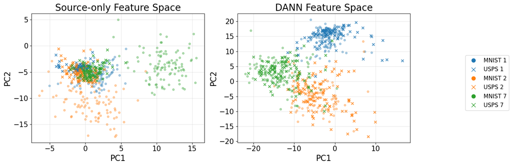

```python
selected_digits = [1, 2, 7]
plot_points_per_digit = 100

source_classifier(np.zeros((1, 28, 28, 1), dtype="float32"), training=False)

source_feature_extractor_for_plot = tf.keras.Model(
    inputs=source_classifier.inputs,
    outputs=source_classifier.layers[-2].output)

pretrain_mnist_feature = source_feature_extractor_for_plot.predict(
    mnist_test_images,
    batch_size=dann_batch_size,
    verbose=0)

pretrain_usps_feature = source_feature_extractor_for_plot.predict(
    usps_test_images,
    batch_size=dann_batch_size,
    verbose=0)

dann_mnist_feature = dann_feature_extractor.predict(
    mnist_test_images,
    batch_size=dann_batch_size,
    verbose=0)

dann_usps_feature = dann_feature_extractor.predict(
    usps_test_images,
    batch_size=dann_batch_size,
    verbose=0)

pretrain_feature_2d = PCA(n_components=2).fit_transform(np.vstack([pretrain_mnist_feature, pretrain_usps_feature]))
dann_feature_2d = PCA(n_components=2).fit_transform(np.vstack([dann_mnist_feature, dann_usps_feature]))

pretrain_mnist_2d = pretrain_feature_2d[:len(pretrain_mnist_feature)]
pretrain_usps_2d = pretrain_feature_2d[len(pretrain_mnist_feature):]

dann_mnist_2d = dann_feature_2d[:len(dann_mnist_feature)]
dann_usps_2d = dann_feature_2d[len(dann_mnist_feature):]

mnist_plot_indices = []
usps_plot_indices = []

for digit in selected_digits:
    mnist_idx = np.where(mnist_test_labels == digit)[0]
    usps_idx = np.where(usps_test_labels == digit)[0]

    mnist_plot_indices.extend(mnist_idx[:plot_points_per_digit])
    usps_plot_indices.extend(usps_idx[:plot_points_per_digit])

mnist_plot_indices = np.array(mnist_plot_indices)
usps_plot_indices = np.array(usps_plot_indices)

fig, axes = plt.subplots(1, 2, figsize=(14, 5))

for color_index, digit in enumerate(selected_digits):
    mnist_idx = mnist_plot_indices[mnist_test_labels[mnist_plot_indices] == digit]
    usps_idx = usps_plot_indices[usps_test_labels[usps_plot_indices] == digit]
    color = f"C{color_index}"

    axes[0].scatter(pretrain_mnist_2d[mnist_idx, 0], pretrain_mnist_2d[mnist_idx, 1], s=18, alpha=0.35, c=color, marker="o")
    axes[0].scatter(pretrain_usps_2d[usps_idx, 0], pretrain_usps_2d[usps_idx, 1], s=28, alpha=0.80, c=color, marker="x")
    axes[1].scatter(dann_mnist_2d[mnist_idx, 0], dann_mnist_2d[mnist_idx, 1], s=18, alpha=0.35, c=color, marker="o")
    axes[1].scatter(dann_usps_2d[usps_idx, 0], dann_usps_2d[usps_idx, 1], s=28, alpha=0.80, c=color, marker="x")

axes[0].set_title("Source-only Feature Space", fontsize=20)
axes[1].set_title("DANN Feature Space", fontsize=20)

for ax in axes:
    ax.set_xlabel("PC1", fontsize=17)
    ax.set_ylabel("PC2", fontsize=17)
    ax.tick_params(axis="both", labelsize=15)
    ax.grid(alpha=0.3)

legend_handles = []
for color_index, digit in enumerate(selected_digits):
    color = f"C{color_index}"

    legend_handles.append(Line2D([0], [0], marker="o", color="w", markerfacecolor=color, markeredgecolor=color, markersize=8, label=f"MNIST {digit}"))
    legend_handles.append(Line2D([0], [0], marker="x", color=color, markersize=8, linewidth=0, label=f"USPS {digit}"))

fig.legend(handles=legend_handles, loc="center left", bbox_to_anchor=(0.98, 0.5),fontsize=12)

plt.tight_layout(rect=[0, 0, 0.88, 1])
plt.show()
```

The result provides a visual explanation of why DANN outperforms the source-only baseline, by showing the learned feature spaces of the two models projected onto two principal components.

In the source-only feature space (left), the MNIST samples (circles) and USPS samples (crosses) of the same digit class are clearly separated from each other. The decision boundary learned from the source domain does not transfer well to the target domain.

In the DANN feature space (right), the picture is strikingly different. The MNIST and USPS samples of the same digit class are now interleaved and occupy overlapping regions — MNIST 1 and USPS 1 cluster together, as do MNIST 2 and USPS 2, and MNIST 7 and USPS 7. The features are now organized by class rather than by domain, confirming that the adversarial training has successfully suppressed domain-specific information while preserving class-discriminative structure.

This visualization directly illustrates the goal of adversarial domain adaptation: to learn a feature space in which the source and target distributions are aligned, so that a classifier trained on labeled source features generalizes naturally to unlabeled target features.

# 4. Discrepancy-based Domain Adaptation

## 4.1. CORAL: CORrelation ALignment

While adversarial domain adaptation aligns source and target distributions through a learned domain classifier, discrepancy-based methods take a more direct approach — they explicitly measure and minimize a statistical distance between the source and target feature distributions.

CORAL is one of the simplest and most interpretable methods in this category. If we assume that the source and target feature distributions can be approximated as Gaussian, then the distribution is fully characterized by its first-order statistics (mean) and second-order statistics (covariance). CORAL focuses on aligning the covariance structure of the source and target features — under this assumption, matching the covariance is sufficient to align the shape and spread of the two distributions.

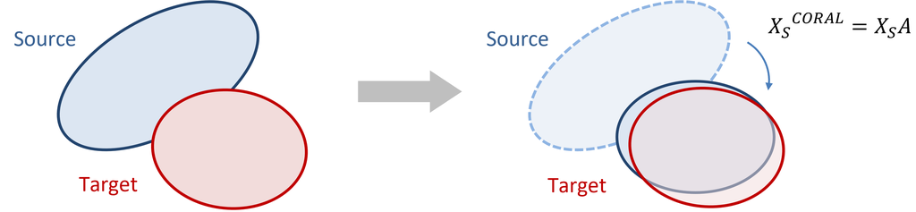

The figure illustrates the intuition. On the left, the source and target feature distributions are misaligned — they occupy different regions and have different shapes in the feature space. On the right, the source distribution has been transformed to overlap with the target distribution by matching its covariance structure.

The goal of CORAL is to find a linear transformation $A$ that minimizes the difference between the transformed source covariance and the target covariance, measured by the norm:

$$\min_A \left\| A^T C_S A - C_T \right\|^2$$

This objective has a closed-form solution — $A$ can be computed analytically from the sample covariances of the source and target features, without requiring any iterative optimization. Once $A$ is obtained, the transformed source features $X_S^{\text{CORAL}} = X_S A$ are used to train a classifier that generalizes to the target domain.

## 4.2. DeepCORAL

CORAL as described above is a fixed linear transformation applied to pre-extracted features. DeepCORAL extends this idea by integrating the CORAL objective directly into neural network training, allowing the feature representations themselves to be learned with reduced covariance discrepancy.

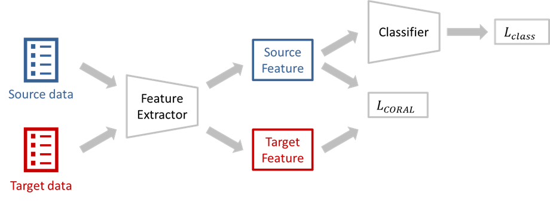

The figure illustrates the framework. Both source and target data are passed through a shared feature extractor. The extracted source and target features are used to compute their respective covariance matrices, and the CORAL loss penalizes the difference between the two. At the same time, the source features are passed to a classifier trained with the standard cross-entropy loss on the source labels.

The total training objective combines the two losses:

$$\mathcal{L} = \mathcal{L}_{\text{class}}^{\text{source}} + \lambda \mathcal{L}_{\text{CORAL}}$$

where the CORAL loss is defined as:

$$\mathcal{L}_{\text{CORAL}} = \frac{1}{4d^2} \left\| C_S - C_T \right\|_F^2$$

- $\mathcal{L}_{\text{class}}^{\text{source}}$: classification loss computed on labeled source data — ensures that the learned features remain discriminative for the task
- $\mathcal{L}_{\text{CORAL}}$: covariance discrepancy between source and target features — encourages the feature extractor to produce representations with aligned second-order statistics across the two domains
- $d$: feature dimension, used for normalization

The hyperparameter $\lambda$ controls the trade-off between the two objectives. By jointly optimizing classification accuracy and covariance alignment, DeepCORAL learns feature representations that are both task-discriminative and domain-invariant — without requiring any adversarial training or labeled target data.

```python
coral_feature_extractor = tf.keras.models.Sequential([
    tf.keras.layers.Input(shape=(28, 28, 1)),
    tf.keras.layers.Conv2D(32, kernel_size=7, activation="relu", padding="same"),
    tf.keras.layers.MaxPool2D(pool_size=2),
    tf.keras.layers.Conv2D(64, kernel_size=7, activation="relu", padding="same"),
    tf.keras.layers.MaxPool2D(pool_size=2),
    tf.keras.layers.Flatten(),
    tf.keras.layers.Dense(128, activation="relu"),], name="coral_feature_extractor")

coral_feature_extractor.layers[0].set_weights(source_classifier.layers[0].get_weights())
coral_feature_extractor.layers[2].set_weights(source_classifier.layers[2].get_weights())
coral_feature_extractor.layers[5].set_weights(source_classifier.layers[5].get_weights())
```

```python
coral_feature_extractor.summary()
```

```
Model: "coral_feature_extractor"
```

```
┏━━━━━━━━━━━━━━━━━━━━━━━━━━━━━━━━━┳━━━━━━━━━━━━━━━━━━━━━━━━┳━━━━━━━━━━━━━━━┓
┃ Layer (type)                    ┃ Output Shape           ┃       Param # ┃
┡━━━━━━━━━━━━━━━━━━━━━━━━━━━━━━━━━╇━━━━━━━━━━━━━━━━━━━━━━━━╇━━━━━━━━━━━━━━━┩
│ conv2d_34 (Conv2D)              │ (None, 28, 28, 32)     │         1,600 │
├─────────────────────────────────┼────────────────────────┼───────────────┤
│ max_pooling2d_6 (MaxPooling2D)  │ (None, 14, 14, 32)     │             0 │
├─────────────────────────────────┼────────────────────────┼───────────────┤
│ conv2d_35 (Conv2D)              │ (None, 14, 14, 64)     │       100,416 │
├─────────────────────────────────┼────────────────────────┼───────────────┤
│ max_pooling2d_7 (MaxPooling2D)  │ (None, 7, 7, 64)       │             0 │
├─────────────────────────────────┼────────────────────────┼───────────────┤
│ flatten_3 (Flatten)             │ (None, 3136)           │             0 │
├─────────────────────────────────┼────────────────────────┼───────────────┤
│ dense_8 (Dense)                 │ (None, 128)            │       401,536 │
└─────────────────────────────────┴────────────────────────┴───────────────┘
```

```
 Total params: 503,552 (1.92 MB)
```

```
 Trainable params: 503,552 (1.92 MB)
```

```
 Non-trainable params: 0 (0.00 B)
```

```python
coral_label_classifier = tf.keras.models.Sequential([
    tf.keras.layers.Input(shape=(128,)),
    tf.keras.layers.Dense(10, activation="softmax")], name="coral_label_classifier")

coral_label_classifier.layers[0].set_weights(source_classifier.layers[6].get_weights())
```

```python
coral_label_classifier.summary()
```

```
Model: "coral_label_classifier"
```

```
┏━━━━━━━━━━━━━━━━━━━━━━━━━━━━━━━━━┳━━━━━━━━━━━━━━━━━━━━━━━━┳━━━━━━━━━━━━━━━┓
┃ Layer (type)                    ┃ Output Shape           ┃       Param # ┃
┡━━━━━━━━━━━━━━━━━━━━━━━━━━━━━━━━━╇━━━━━━━━━━━━━━━━━━━━━━━━╇━━━━━━━━━━━━━━━┩
│ dense_9 (Dense)                 │ (None, 10)             │         1,290 │
└─────────────────────────────────┴────────────────────────┴───────────────┘
```

```
 Total params: 1,290 (5.04 KB)
```

```
 Trainable params: 1,290 (5.04 KB)
```

```
 Non-trainable params: 0 (0.00 B)
```

```python
coral_classifier_model = tf.keras.models.Sequential([
    coral_feature_extractor,
    coral_label_classifier], name="coral_classifier_model")

coral_feature_optimizer = tf.keras.optimizers.Adam(learning_rate=1e-4)
coral_label_optimizer = tf.keras.optimizers.Adam(learning_rate=2e-4)

coral_class_loss_fn = tf.keras.losses.SparseCategoricalCrossentropy()
```

```python
coral_classifier_model.summary()
```

```
Model: "coral_classifier_model"
```

```
┏━━━━━━━━━━━━━━━━━━━━━━━━━━━━━━━━━┳━━━━━━━━━━━━━━━━━━━━━━━━┳━━━━━━━━━━━━━━━┓
┃ Layer (type)                    ┃ Output Shape           ┃       Param # ┃
┡━━━━━━━━━━━━━━━━━━━━━━━━━━━━━━━━━╇━━━━━━━━━━━━━━━━━━━━━━━━╇━━━━━━━━━━━━━━━┩
│ coral_feature_extractor         │ (None, 128)            │       503,552 │
│ (Sequential)                    │                        │               │
├─────────────────────────────────┼────────────────────────┼───────────────┤
│ coral_label_classifier          │ (None, 10)             │         1,290 │
│ (Sequential)                    │                        │               │
└─────────────────────────────────┴────────────────────────┴───────────────┘
```

```
 Total params: 504,842 (1.93 MB)
```

```
 Trainable params: 504,842 (1.93 MB)
```

```
 Non-trainable params: 0 (0.00 B)
```

```python
coral_batch_size = 128

coral_source_dataset = tf.data.Dataset.from_tensor_slices((mnist_train_images, mnist_train_labels))
coral_source_dataset = coral_source_dataset.shuffle(len(mnist_train_images))
coral_source_dataset = coral_source_dataset.repeat()
coral_source_dataset = coral_source_dataset.batch(coral_batch_size)

coral_target_dataset = tf.data.Dataset.from_tensor_slices(usps_train_images)
coral_target_dataset = coral_target_dataset.shuffle(len(usps_train_images))
coral_target_dataset = coral_target_dataset.repeat()
coral_target_dataset = coral_target_dataset.batch(coral_batch_size)

coral_source_iter = iter(coral_source_dataset)
coral_target_iter = iter(coral_target_dataset)

coral_steps_per_epoch = len(usps_train_images) // coral_batch_size
```

```python
coral_epochs = 100
coral_display_epoch_interval = 10
coral_weight = 500.0

for epoch in range(1, coral_epochs + 1):
    total_loss_sum = 0.0
    class_loss_sum = 0.0
    coral_loss_sum = 0.0

    for _ in range(coral_steps_per_epoch):
        source_x, source_y = next(coral_source_iter)
        target_x = next(coral_target_iter)

        with tf.GradientTape(persistent=True) as tape:
            source_feature = coral_feature_extractor(source_x, training=True)
            target_feature = coral_feature_extractor(target_x, training=True)

            source_class_prob = coral_label_classifier(source_feature, training=True)
            class_loss = coral_class_loss_fn(source_y, source_class_prob)

            source_centered = source_feature - tf.reduce_mean(source_feature, axis=0, keepdims=True)
            target_centered = target_feature - tf.reduce_mean(target_feature, axis=0, keepdims=True)

            batch_size_float = tf.cast(tf.shape(source_feature)[0], tf.float32)
            feature_dim_float = tf.cast(tf.shape(source_feature)[1], tf.float32)

            source_covariance = tf.matmul(source_centered, source_centered, transpose_a=True) / (batch_size_float - 1.0)
            target_covariance = tf.matmul(target_centered, target_centered, transpose_a=True) / (batch_size_float - 1.0)

            coral_loss = tf.reduce_sum(
                tf.square(source_covariance - target_covariance)) / (4.0 * feature_dim_float * feature_dim_float)

            total_loss = class_loss + coral_weight * coral_loss

        coral_feature_optimizer.apply_gradients(
            zip(tape.gradient(total_loss,
                              coral_feature_extractor.trainable_variables),
                coral_feature_extractor.trainable_variables))

        coral_label_optimizer.apply_gradients(
            zip(tape.gradient(total_loss,
                              coral_label_classifier.trainable_variables),
                coral_label_classifier.trainable_variables))
        del tape

        total_loss_sum += float(total_loss)
        class_loss_sum += float(class_loss)
        coral_loss_sum += float(coral_loss)

    total_loss_mean = total_loss_sum / coral_steps_per_epoch
    class_loss_mean = class_loss_sum / coral_steps_per_epoch
    coral_loss_mean = coral_loss_sum / coral_steps_per_epoch
    scaled_coral_loss_mean = coral_weight * coral_loss_mean

    coral_mnist_prob = coral_classifier_model.predict(
        mnist_test_images,
        batch_size=coral_batch_size,
        verbose=0)

    coral_usps_prob = coral_classifier_model.predict(
        usps_test_images,
        batch_size=coral_batch_size,
        verbose=0)

    coral_mnist_pred = np.argmax(coral_mnist_prob, axis=1)
    coral_usps_pred = np.argmax(coral_usps_prob, axis=1)

    coral_mnist_acc = np.mean(coral_mnist_pred == mnist_test_labels.reshape(-1))
    coral_usps_acc = np.mean(coral_usps_pred == usps_test_labels.reshape(-1))

    if epoch == 1 or epoch % coral_display_epoch_interval == 0 or epoch == coral_epochs:
        print(
            f"Epoch {epoch:03d}/{coral_epochs} | "
            f"total={total_loss_mean:.4f} | "
            f"class={class_loss_mean:.4f} | "
            f"coral={coral_loss_mean:.6f} | "
            f"scaled_coral={scaled_coral_loss_mean:.4f} | "
            f"MNIST_acc={coral_mnist_acc:.4f} | "
        )
```

[output not shown]

```python
coral_mnist_prob = coral_classifier_model.predict(mnist_test_images, batch_size=coral_batch_size, verbose=0)
coral_usps_prob = coral_classifier_model.predict(usps_test_images, batch_size=coral_batch_size, verbose=0)

coral_mnist_pred = np.argmax(coral_mnist_prob, axis=1)
coral_usps_pred = np.argmax(coral_usps_prob, axis=1)

coral_mnist_acc = np.mean(coral_mnist_pred == mnist_test_labels.reshape(-1))
coral_usps_acc = np.mean(coral_usps_pred == usps_test_labels.reshape(-1))

print("[Source-only]")
print(f"MNIST accuracy: {source_mnist_acc:.4f}")
print(f"USPS accuracy : {source_usps_acc:.4f}")

print("\n[Deep CORAL]")
print(f"MNIST accuracy: {coral_mnist_acc:.4f}")
print(f"USPS accuracy : {coral_usps_acc:.4f}")
print(f"USPS improvement over source-only: {coral_usps_acc - source_usps_acc:+.4f}")
```

```
[Source-only]
MNIST accuracy: 0.9856
USPS accuracy : 0.7414

[Deep CORAL]
MNIST accuracy: 0.9930
USPS accuracy : 0.9038
USPS improvement over source-only: +0.1624
```

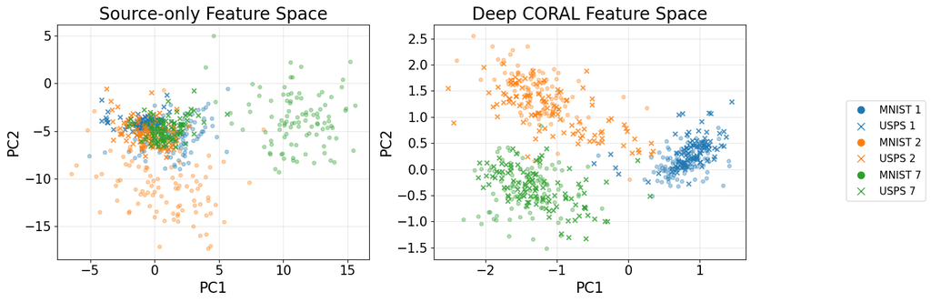

```python
selected_digits = [1, 2, 7]
plot_points_per_digit = 100

mnist_test_labels_1d = mnist_test_labels.reshape(-1)
usps_test_labels_1d = usps_test_labels.reshape(-1)

pretrain_mnist_feature = source_feature_extractor_for_plot.predict(
    mnist_test_images,
    batch_size=coral_batch_size,
    verbose=0)
pretrain_usps_feature = source_feature_extractor_for_plot.predict(
    usps_test_images,
    batch_size=coral_batch_size,
    verbose=0)

coral_mnist_feature = coral_feature_extractor.predict(
    mnist_test_images,
    batch_size=coral_batch_size,
    verbose=0)
coral_usps_feature = coral_feature_extractor.predict(
    usps_test_images,
    batch_size=coral_batch_size,
    verbose=0)

pretrain_feature_2d = PCA(n_components=2).fit_transform(np.vstack([pretrain_mnist_feature, pretrain_usps_feature]))
coral_feature_2d = PCA(n_components=2).fit_transform(np.vstack([coral_mnist_feature, coral_usps_feature]))

pretrain_mnist_2d = pretrain_feature_2d[:len(pretrain_mnist_feature)]
pretrain_usps_2d = pretrain_feature_2d[len(pretrain_mnist_feature):]

coral_mnist_2d = coral_feature_2d[:len(coral_mnist_feature)]
coral_usps_2d = coral_feature_2d[len(coral_mnist_feature):]

mnist_plot_indices = []
usps_plot_indices = []

for digit in selected_digits:
    mnist_idx = np.where(mnist_test_labels_1d == digit)[0]
    usps_idx = np.where(usps_test_labels_1d == digit)[0]

    mnist_plot_indices.extend(mnist_idx[:plot_points_per_digit])
    usps_plot_indices.extend(usps_idx[:plot_points_per_digit])

mnist_plot_indices = np.array(mnist_plot_indices)
usps_plot_indices = np.array(usps_plot_indices)

fig, axes = plt.subplots(1, 2, figsize=(14, 5))

for color_index, digit in enumerate(selected_digits):
    mnist_idx = mnist_plot_indices[mnist_test_labels_1d[mnist_plot_indices] == digit]
    usps_idx = usps_plot_indices[usps_test_labels_1d[usps_plot_indices] == digit]
    color = f"C{color_index}"

    axes[0].scatter(pretrain_mnist_2d[mnist_idx, 0], pretrain_mnist_2d[mnist_idx, 1], s=18, alpha=0.35, c=color, marker="o")
    axes[0].scatter(pretrain_usps_2d[usps_idx, 0], pretrain_usps_2d[usps_idx, 1], s=28, alpha=0.80, c=color, marker="x")
    axes[1].scatter(coral_mnist_2d[mnist_idx, 0], coral_mnist_2d[mnist_idx, 1], s=18, alpha=0.35, c=color, marker="o")
    axes[1].scatter(coral_usps_2d[usps_idx, 0], coral_usps_2d[usps_idx, 1], s=28, alpha=0.80, c=color, marker="x")

axes[0].set_title("Source-only Feature Space", fontsize=20)
axes[1].set_title("Deep CORAL Feature Space", fontsize=20)

for ax in axes:
    ax.set_xlabel("PC1", fontsize=17)
    ax.set_ylabel("PC2", fontsize=17)
    ax.tick_params(axis="both", labelsize=15)
    ax.grid(alpha=0.3)

legend_handles = []
for color_index, digit in enumerate(selected_digits):
    color = f"C{color_index}"

    legend_handles.append(Line2D([0], [0], marker="o", color="w", markerfacecolor=color, markeredgecolor=color, markersize=8, label=f"MNIST {digit}"))
    legend_handles.append(Line2D([0], [0], marker="x", color=color, markersize=8, linewidth=0, label=f"USPS {digit}"))

fig.legend(handles=legend_handles, loc="center left", bbox_to_anchor=(0.98, 0.5), fontsize=12)

plt.tight_layout(rect=[0, 0, 0.88, 1])
plt.show()
```

```python
summary_rows = [{"method": "Source-only", "mnist_acc": source_mnist_acc, "usps_acc": source_usps_acc, "usps_improvement": 0.0},
                {"method": "CycleGAN", "mnist_acc": cycle_mnist_acc, "usps_acc": cycle_usps_acc, "usps_improvement": cycle_usps_acc - source_usps_acc,},
                {"method": "DANN", "mnist_acc": dann_mnist_acc, "usps_acc": dann_usps_acc, "usps_improvement": dann_usps_acc - source_usps_acc,},
                {"method": "Deep CORAL", "mnist_acc": coral_mnist_acc, "usps_acc": coral_usps_acc, "usps_improvement": coral_usps_acc - source_usps_acc,}]

print("Domain Adaptation Summary")
print("-" * 78)
print(
    f"{'Method':<28} "
    f"{'MNIST Acc':>12} "
    f"{'USPS Acc':>12} "
    f"{'USPS Improvement':>18}")
print("-" * 78)

for row in summary_rows:
    print(
        f"{row['method']:<28} "
        f"{row['mnist_acc']:>12.4f} "
        f"{row['usps_acc']:>12.4f} "
        f"{row['usps_improvement']:>+18.4f}")
print("-" * 78)
```

```
Domain Adaptation Summary
------------------------------------------------------------------------------
Method                          MNIST Acc     USPS Acc   USPS Improvement
------------------------------------------------------------------------------
Source-only                        0.9856       0.7414            +0.0000
CycleGAN                           0.9880       0.8979            +0.1565
DANN                               0.9917       0.9427            +0.2013
Deep CORAL                         0.9930       0.9038            +0.1624
------------------------------------------------------------------------------
```

```python
%%javascript
$.getScript('https://kmahelona.github.io/ipython_notebook_goodies/ipython_notebook_toc.js')
```